# Simulation study for the R1 revision

Author

Shuntaro Sato

Published

2026/10/20, 14:32

# 1 Design (ADEMP)

- **Aims**: to compare Models 2, 3, and 4 for estimating the population change-point (the mean of the participant-specific change-points, which corresponds to the EAR) when change-points do or do not vary among participants, and to evaluate Model 4 for the SD of the change-points and for participant-specific change-points.
- **Data-generating mechanisms**: y = plateau + u0 + (slope + u1) × min(x − cp_i, 0) + e, with cp_i = 0.9 + u3; plateau 1.3, slope −0.8, SD(u0) = SD(u1) = SD(e) = 0.15 (based on the fits to the four datasets); protein intakes 0.1, 0.3, 0.6, 0.9, 1.2, 1.5, and 1.8 g/kg/day. Factors: SD of change-points (0, 0.1, 0.2 g/kg/day) × number of participants (8, 16) × intake levels per participant (all 7, or 4 selected at random) = 12 scenarios; 500 replicates each.
- **Estimands**: population change-point (0.9 g/kg/day), SD of the change-points, participant-specific change-points.
- **Methods**: as in the analysis of the published data. Models 2 and 3: REML profile over candidate change-points from 0 to 2.5 g/kg/day by 0.01, with the AIC-based 95% interval. Model 4: population change-point bounded to (0, 2.5) g/kg/day with a Normal(0, 1) prior on the logit scale; half-normal(0, 0.3) (primary) and half-normal(0, 1) priors for the SD of the change-points; 4 chains of 2000 iterations including 1000 warm-up iterations; point estimates are posterior medians and intervals are 95% equal-tailed credible intervals. Random change-point model of Tang et al. (2014) (only the change-point varies among participants): maximum likelihood with the exact likelihood (Tang (ML)) and with the first-order approximation (Tang (FO)), Wald 95% CI with t quantile (df = participants − 1), change-point restricted to (0, 2.5).
- **Performance measures**: bias, empirical SE, RMSE, and coverage and width of the 95% intervals, with Monte Carlo SEs.

```r
suppressPackageStartupMessages({
  library(tidyverse)
  library(gt)
  library(patchwork)
})
source("simulation/sim_functions.R", echo = FALSE)  # for `scenarios` and `truth`

results_dir <- "simulation/results"
files <- list.files(results_dir, pattern = "^scenario_.*\\.rds$", full.names = TRUE)
raw <- map(files, read_rds)
stopifnot(all(map_chr(raw, ~ .x$models23_grid %||% "") == "0-2.5"), all(map_lgl(raw, ~ isTRUE(.x$tang_added))),
          all(map_chr(raw, ~ .x$model4_point %||% "") == "median"))

flatten_results <- function(x, what) {
  map_dfr(x$results, function(r) {
    if (!is.null(r$error)) return(NULL)
    r[[what]] |> mutate(rep = r$rep)
  }) |>
    mutate(scenario = x$scenario$scenario)
}

# Models 2 and 3: a limit is missing when the AIC does not exceed its minimum by 4 within the
# range of candidate change-points; the interval then extends to the end of the range (0 or 2.5),
# as the credible interval of Model 4 is confined to the same range.
cp_range <- c(0, 2.5)
pop <- map_dfr(raw, flatten_results, what = "pop") |>
  distinct(scenario, rep, method, .keep_all = TRUE) |>
  left_join(scenarios, by = "scenario") |>
  mutate(
    m23 = method %in% c("Model 2", "Model 3"),
    open_limit = m23 & !is.na(est) & (is.na(lower) | is.na(upper)),
    lower = if_else(m23 & !is.na(est) & is.na(lower), cp_range[1], lower),
    upper = if_else(m23 & !is.na(est) & is.na(upper), cp_range[2], upper),
    no_interval = is.na(lower) | is.na(upper),
    covered = !no_interval & lower <= truth$cp & upper >= truth$cp
  )
ind <- map_dfr(raw, flatten_results, what = "ind") |>
  distinct(scenario, rep, method, id, .keep_all = TRUE) |>
  left_join(scenarios, by = "scenario")
n_errors <- sum(map_int(raw, ~ sum(map_lgl(.x$results, function(r) !is.null(r$error)))))

scen_lab <- function(n, l) factor(sprintf("n = %d, %s", n, ifelse(l == 7, "7 levels", "4 of 7 levels")),
                                  levels = c("n = 8, 7 levels", "n = 8, 4 of 7 levels",
                                             "n = 16, 7 levels", "n = 16, 4 of 7 levels"))
method_colors <- c("Model 2" = "#4269d0", "Model 3" = "#6cc5b0",
                   "Model 4 (HN 0.3)" = "#ff725c", "Model 4 (HN 1)" = "#a0522d",
                   "Tang (ML)" = "#9b59b6", "Tang (FO)" = "#d4a017")
method_levels <- names(method_colors)
dir.create("output", showWarnings = FALSE)
```

Replicates per scenario and method: 500–500; replicates with errors: 0.

# 2 Population change-point

```r
perf_pop <- pop |>
  group_by(scenario, sd_cp, n, levels_per_participant, method) |>
  summarise(
    n_rep = n(),
    n_est = sum(!is.na(est)),
    no_estimate = mean(is.na(est)),
    bias = mean(est - truth$cp, na.rm = TRUE),
    emp_se = sd(est, na.rm = TRUE),
    rmse = sqrt(mean((est - truth$cp)^2, na.rm = TRUE)),
    coverage = mean(covered),
    width = mean(upper - lower, na.rm = TRUE),
    open_limit = mean(open_limit),
    no_interval = mean(no_interval),
    divergent_any = mean(n_divergent > 0, na.rm = TRUE),
    rhat_gt_1.01 = mean(max_rhat > 1.01, na.rm = TRUE),
    secs = mean(secs, na.rm = TRUE),
    .groups = "drop"
  ) |>
  mutate(mcse_bias = emp_se / sqrt(n_est),
         mcse_coverage = sqrt(coverage * (1 - coverage) / n_rep),
         across(c(divergent_any, rhat_gt_1.01), ~ if_else(is.nan(.x), NA_real_, .x)))
write_csv(perf_pop, "output/simulation_population.csv")

# Model 4 excluding replicates with divergent transitions or R-hat > 1.01 (sensitivity check)
perf_conv <- pop |>
  filter(str_detect(method, "Model 4"), n_divergent == 0, max_rhat <= 1.01) |>
  group_by(scenario, sd_cp, n, levels_per_participant, method) |>
  summarise(n_rep = n(), bias = mean(est - truth$cp), coverage = mean(covered), .groups = "drop")
write_csv(perf_conv, "output/simulation_population_converged.csv")

# Table 3 of the manuscript (primary prior for Model 4)
table3 <- perf_pop |>
  filter(method %in% c("Model 2", "Model 3", "Model 4 (HN 0.3)")) |>
  mutate(method = recode(method, "Model 4 (HN 0.3)" = "Model 4")) |>
  select(sd_cp, n, levels_per_participant, method, bias, rmse, coverage) |>
  pivot_wider(names_from = method, values_from = c(bias, rmse, coverage), names_glue = "{method}_{.value}") |>
  arrange(sd_cp, n, desc(levels_per_participant))
write_csv(table3, "output/table3_simulation.csv")

# Model 4 vs the random change-point model of Tang et al. (2014)
table_tang <- perf_pop |>
  filter(method %in% c("Model 4 (HN 0.3)", "Tang (ML)", "Tang (FO)")) |>
  select(sd_cp, n, levels_per_participant, method, bias, rmse, coverage, width) |>
  pivot_wider(names_from = method, values_from = c(bias, rmse, coverage, width), names_glue = "{method}_{.value}") |>
  arrange(sd_cp, n, desc(levels_per_participant))
write_csv(table_tang, "output/table_simulation_tang.csv")

perf_pop |>
  mutate(design = scen_lab(n, levels_per_participant)) |>
  select(sd_cp, design, method, n_est, no_estimate, bias, mcse_bias, emp_se, rmse, coverage, mcse_coverage,
         width, open_limit, divergent_any, rhat_gt_1.01) |>
  gt(groupname_col = "design") |>
  fmt_number(columns = c(bias, mcse_bias, emp_se, rmse, width), decimals = 3) |>
  fmt_percent(columns = c(no_estimate, coverage, mcse_coverage, open_limit, divergent_any, rhat_gt_1.01), decimals = 1)
```

| sd_cp | method | n_est | no_estimate | bias | mcse_bias | emp_se | rmse | coverage | mcse_coverage | width | open_limit | divergent_any | rhat_gt_1.01 |
| --- | --- | --- | --- | --- | --- | --- | --- | --- | --- | --- | --- | --- | --- |
| n = 8, 7 levels |  |  |  |  |  |  |  |  |  |  |  |  |  |
| 0.0 | Model 2 | 500 | 0.0% | −0.024 | 0.004 | 0.091 | 0.095 | 95.8% | 0.9% | 0.374 | 0.0% | NA | NA |
| 0.0 | Model 3 | 500 | 0.0% | −0.016 | 0.007 | 0.146 | 0.147 | 92.8% | 1.2% | 0.431 | 0.4% | NA | NA |
| 0.0 | Model 4 (HN 0.3) | 500 | 0.0% | −0.024 | 0.004 | 0.089 | 0.093 | 96.0% | 0.9% | 0.441 | 0.0% | 0.0% | 0.2% |
| 0.0 | Model 4 (HN 1) | 500 | 0.0% | −0.022 | 0.004 | 0.092 | 0.094 | 96.8% | 0.8% | 0.470 | 0.0% | 0.6% | 0.8% |
| 0.0 | Tang (FO) | 500 | 0.0% | 0.108 | 0.014 | 0.304 | 0.322 | 85.8% | 1.6% | 3,974.314 | 0.0% | NA | NA |
| 0.0 | Tang (ML) | 500 | 0.0% | 0.127 | 0.016 | 0.364 | 0.385 | 92.8% | 1.2% | 0.787 | 0.0% | NA | NA |
| 0.1 | Model 2 | 500 | 0.0% | −0.004 | 0.005 | 0.114 | 0.114 | 93.6% | 1.1% | 0.435 | 0.6% | NA | NA |
| 0.1 | Model 3 | 500 | 0.0% | 0.006 | 0.006 | 0.141 | 0.141 | 91.8% | 1.2% | 0.473 | 1.0% | NA | NA |
| 0.1 | Model 4 (HN 0.3) | 500 | 0.0% | 0.002 | 0.005 | 0.108 | 0.108 | 96.2% | 0.9% | 0.502 | 0.0% | 0.4% | 2.6% |
| 0.1 | Model 4 (HN 1) | 500 | 0.0% | 0.005 | 0.005 | 0.111 | 0.111 | 97.6% | 0.7% | 0.547 | 0.0% | 0.4% | 1.4% |
| 0.1 | Tang (FO) | 500 | 0.0% | 0.151 | 0.015 | 0.333 | 0.365 | 83.8% | 1.6% | 9,723.488 | 0.0% | NA | NA |
| 0.1 | Tang (ML) | 500 | 0.0% | 0.199 | 0.019 | 0.421 | 0.466 | 87.8% | 1.5% | 0.872 | 0.0% | NA | NA |
| 0.2 | Model 2 | 500 | 0.0% | 0.015 | 0.007 | 0.146 | 0.147 | 90.4% | 1.3% | 0.527 | 0.6% | NA | NA |
| 0.2 | Model 3 | 500 | 0.0% | 0.063 | 0.007 | 0.163 | 0.174 | 78.0% | 1.9% | 0.485 | 1.0% | NA | NA |
| 0.2 | Model 4 (HN 0.3) | 500 | 0.0% | 0.024 | 0.006 | 0.129 | 0.131 | 96.8% | 0.8% | 0.587 | 0.0% | 0.2% | 3.0% |
| 0.2 | Model 4 (HN 1) | 500 | 0.0% | 0.027 | 0.006 | 0.131 | 0.134 | 98.4% | 0.6% | 0.665 | 0.0% | 1.8% | 3.4% |
| 0.2 | Tang (FO) | 500 | 0.0% | 0.146 | 0.014 | 0.318 | 0.350 | 82.8% | 1.7% | 3,534.286 | 0.0% | NA | NA |
| 0.2 | Tang (ML) | 500 | 0.0% | 0.182 | 0.017 | 0.379 | 0.420 | 90.0% | 1.3% | 0.922 | 0.0% | NA | NA |
| n = 8, 4 of 7 levels |  |  |  |  |  |  |  |  |  |  |  |  |  |
| 0.0 | Model 2 | 500 | 0.0% | −0.052 | 0.010 | 0.219 | 0.225 | 89.0% | 1.4% | 0.583 | 7.0% | NA | NA |
| 0.0 | Model 3 | 499 | 0.2% | −0.002 | 0.015 | 0.327 | 0.327 | 90.6% | 1.3% | 0.960 | 23.6% | NA | NA |
| 0.0 | Model 4 (HN 0.3) | 500 | 0.0% | −0.032 | 0.007 | 0.156 | 0.159 | 96.2% | 0.9% | 0.736 | 0.0% | 3.4% | 3.4% |
| 0.0 | Model 4 (HN 1) | 500 | 0.0% | −0.024 | 0.007 | 0.160 | 0.161 | 98.0% | 0.6% | 0.808 | 0.0% | 8.2% | 3.2% |
| 0.0 | Tang (FO) | 500 | 0.0% | 0.126 | 0.016 | 0.355 | 0.376 | 76.2% | 1.9% | 5,676.715 | 0.0% | NA | NA |
| 0.0 | Tang (ML) | 500 | 0.0% | 0.141 | 0.019 | 0.429 | 0.451 | 88.4% | 1.4% | 0.946 | 0.0% | NA | NA |
| 0.1 | Model 2 | 500 | 0.0% | −0.034 | 0.011 | 0.243 | 0.245 | 86.0% | 1.6% | 0.641 | 10.4% | NA | NA |
| 0.1 | Model 3 | 498 | 0.4% | 0.040 | 0.015 | 0.327 | 0.329 | 89.6% | 1.4% | 0.985 | 22.8% | NA | NA |
| 0.1 | Model 4 (HN 0.3) | 500 | 0.0% | −0.007 | 0.008 | 0.174 | 0.174 | 96.6% | 0.8% | 0.801 | 0.0% | 2.6% | 0.8% |
| 0.1 | Model 4 (HN 1) | 500 | 0.0% | 0.004 | 0.008 | 0.179 | 0.179 | 97.6% | 0.7% | 0.883 | 0.0% | 5.8% | 3.2% |
| 0.1 | Tang (FO) | 500 | 0.0% | 0.160 | 0.016 | 0.363 | 0.396 | 70.0% | 2.0% | 8,439.702 | 0.0% | NA | NA |
| 0.1 | Tang (ML) | 500 | 0.0% | 0.196 | 0.020 | 0.457 | 0.497 | 83.4% | 1.7% | 5.753 | 0.0% | NA | NA |
| 0.2 | Model 2 | 500 | 0.0% | −0.060 | 0.013 | 0.295 | 0.301 | 84.2% | 1.6% | 0.722 | 15.6% | NA | NA |
| 0.2 | Model 3 | 500 | 0.0% | 0.063 | 0.014 | 0.323 | 0.329 | 88.4% | 1.4% | 0.975 | 23.2% | NA | NA |
| 0.2 | Model 4 (HN 0.3) | 500 | 0.0% | 0.007 | 0.008 | 0.178 | 0.178 | 98.6% | 0.5% | 0.869 | 0.0% | 2.6% | 3.4% |
| 0.2 | Model 4 (HN 1) | 500 | 0.0% | 0.016 | 0.008 | 0.179 | 0.179 | 99.0% | 0.4% | 0.962 | 0.0% | 9.2% | 5.4% |
| 0.2 | Tang (FO) | 500 | 0.0% | 0.130 | 0.014 | 0.309 | 0.334 | 76.4% | 1.9% | 1,248.473 | 0.0% | NA | NA |
| 0.2 | Tang (ML) | 500 | 0.0% | 0.139 | 0.017 | 0.389 | 0.413 | 91.0% | 1.3% | 1.033 | 0.0% | NA | NA |
| n = 16, 7 levels |  |  |  |  |  |  |  |  |  |  |  |  |  |
| 0.0 | Model 2 | 500 | 0.0% | −0.013 | 0.003 | 0.060 | 0.062 | 97.8% | 0.7% | 0.268 | 0.0% | NA | NA |
| 0.0 | Model 3 | 500 | 0.0% | −0.013 | 0.003 | 0.068 | 0.069 | 96.6% | 0.8% | 0.259 | 0.0% | NA | NA |
| 0.0 | Model 4 (HN 0.3) | 500 | 0.0% | −0.018 | 0.003 | 0.056 | 0.059 | 97.2% | 0.7% | 0.275 | 0.0% | 0.0% | 3.0% |
| 0.0 | Model 4 (HN 1) | 500 | 0.0% | −0.017 | 0.003 | 0.056 | 0.059 | 97.2% | 0.7% | 0.278 | 0.0% | 0.0% | 3.0% |
| 0.0 | Tang (FO) | 500 | 0.0% | 0.097 | 0.012 | 0.275 | 0.291 | 89.2% | 1.4% | 5,893.038 | 0.0% | NA | NA |
| 0.0 | Tang (ML) | 500 | 0.0% | 0.134 | 0.015 | 0.325 | 0.351 | 88.6% | 1.4% | 0.559 | 0.0% | NA | NA |
| 0.1 | Model 2 | 500 | 0.0% | 0.006 | 0.004 | 0.084 | 0.084 | 91.8% | 1.2% | 0.303 | 0.0% | NA | NA |
| 0.1 | Model 3 | 500 | 0.0% | 0.014 | 0.004 | 0.084 | 0.085 | 89.6% | 1.4% | 0.287 | 0.0% | NA | NA |
| 0.1 | Model 4 (HN 0.3) | 500 | 0.0% | 0.002 | 0.003 | 0.077 | 0.077 | 96.8% | 0.8% | 0.319 | 0.0% | 0.0% | 3.4% |
| 0.1 | Model 4 (HN 1) | 500 | 0.0% | 0.002 | 0.003 | 0.077 | 0.077 | 96.4% | 0.8% | 0.325 | 0.0% | 0.0% | 5.8% |
| 0.1 | Tang (FO) | 500 | 0.0% | 0.133 | 0.013 | 0.294 | 0.322 | 84.6% | 1.6% | 8,548.759 | 0.0% | NA | NA |
| 0.1 | Tang (ML) | 500 | 0.0% | 0.163 | 0.014 | 0.318 | 0.357 | 85.8% | 1.6% | 0.602 | 0.0% | NA | NA |
| 0.2 | Model 2 | 500 | 0.0% | 0.019 | 0.005 | 0.110 | 0.111 | 84.0% | 1.6% | 0.354 | 0.0% | NA | NA |
| 0.2 | Model 3 | 500 | 0.0% | 0.054 | 0.005 | 0.110 | 0.123 | 71.4% | 2.0% | 0.315 | 0.0% | NA | NA |
| 0.2 | Model 4 (HN 0.3) | 500 | 0.0% | 0.012 | 0.004 | 0.094 | 0.095 | 95.4% | 0.9% | 0.383 | 0.0% | 0.0% | 6.4% |
| 0.2 | Model 4 (HN 1) | 500 | 0.0% | 0.012 | 0.004 | 0.094 | 0.094 | 96.2% | 0.9% | 0.399 | 0.0% | 0.0% | 9.0% |
| 0.2 | Tang (FO) | 500 | 0.0% | 0.142 | 0.013 | 0.294 | 0.326 | 84.0% | 1.6% | 2,493.499 | 0.0% | NA | NA |
| 0.2 | Tang (ML) | 500 | 0.0% | 0.139 | 0.011 | 0.256 | 0.291 | 87.6% | 1.5% | 0.606 | 0.0% | NA | NA |
| n = 16, 4 of 7 levels |  |  |  |  |  |  |  |  |  |  |  |  |  |
| 0.0 | Model 2 | 500 | 0.0% | −0.017 | 0.004 | 0.096 | 0.097 | 96.0% | 0.9% | 0.370 | 0.0% | NA | NA |
| 0.0 | Model 3 | 500 | 0.0% | −0.008 | 0.007 | 0.157 | 0.158 | 95.0% | 1.0% | 0.407 | 0.4% | NA | NA |
| 0.0 | Model 4 (HN 0.3) | 500 | 0.0% | −0.020 | 0.004 | 0.094 | 0.096 | 96.8% | 0.8% | 0.420 | 0.0% | 0.0% | 3.4% |
| 0.0 | Model 4 (HN 1) | 500 | 0.0% | −0.019 | 0.004 | 0.095 | 0.097 | 97.0% | 0.8% | 0.435 | 0.0% | 0.0% | 5.8% |
| 0.0 | Tang (FO) | 500 | 0.0% | 0.096 | 0.013 | 0.294 | 0.309 | 82.6% | 1.7% | 742.405 | 0.0% | NA | NA |
| 0.0 | Tang (ML) | 500 | 0.0% | 0.088 | 0.013 | 0.289 | 0.302 | 89.8% | 1.4% | 0.608 | 0.0% | NA | NA |
| 0.1 | Model 2 | 500 | 0.0% | −0.006 | 0.005 | 0.122 | 0.122 | 92.6% | 1.2% | 0.424 | 0.4% | NA | NA |
| 0.1 | Model 3 | 500 | 0.0% | 0.002 | 0.006 | 0.133 | 0.133 | 92.4% | 1.2% | 0.451 | 0.8% | NA | NA |
| 0.1 | Model 4 (HN 0.3) | 500 | 0.0% | −0.001 | 0.005 | 0.115 | 0.115 | 95.6% | 0.9% | 0.478 | 0.0% | 0.0% | 6.0% |
| 0.1 | Model 4 (HN 1) | 500 | 0.0% | 0.002 | 0.005 | 0.117 | 0.117 | 96.0% | 0.9% | 0.501 | 0.0% | 0.0% | 8.0% |
| 0.1 | Tang (FO) | 500 | 0.0% | 0.148 | 0.014 | 0.323 | 0.355 | 76.2% | 1.9% | 1,920.663 | 0.0% | NA | NA |
| 0.1 | Tang (ML) | 500 | 0.0% | 0.169 | 0.017 | 0.372 | 0.409 | 85.0% | 1.6% | 0.726 | 0.0% | NA | NA |
| 0.2 | Model 2 | 500 | 0.0% | 0.010 | 0.006 | 0.142 | 0.142 | 91.2% | 1.3% | 0.520 | 1.4% | NA | NA |
| 0.2 | Model 3 | 500 | 0.0% | 0.051 | 0.007 | 0.156 | 0.164 | 85.4% | 1.6% | 0.491 | 1.2% | NA | NA |
| 0.2 | Model 4 (HN 0.3) | 500 | 0.0% | 0.017 | 0.005 | 0.121 | 0.123 | 97.4% | 0.7% | 0.572 | 0.0% | 0.0% | 9.0% |
| 0.2 | Model 4 (HN 1) | 500 | 0.0% | 0.020 | 0.006 | 0.124 | 0.125 | 97.8% | 0.7% | 0.608 | 0.0% | 0.2% | 11.2% |
| 0.2 | Tang (FO) | 500 | 0.0% | 0.147 | 0.014 | 0.304 | 0.337 | 76.8% | 1.9% | 3,268.542 | 0.0% | NA | NA |
| 0.2 | Tang (ML) | 500 | 0.0% | 0.140 | 0.013 | 0.300 | 0.330 | 87.8% | 1.5% | 0.740 | 0.0% | NA | NA |

For Models 2 and 3, `open_limit` is the proportion of replicates in which a limit of the interval was set to the end of the range of candidate change-points, and `no_estimate` is the proportion in which the model could not be fitted at any candidate change-point; these replicates are counted as not covering.

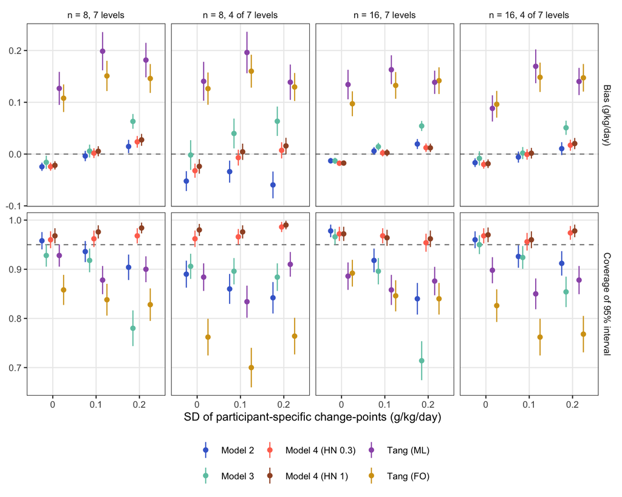

```r
fig_pop <- perf_pop |>
  mutate(design = scen_lab(n, levels_per_participant),
         se_bias = mcse_bias, se_cov = mcse_coverage) |>
  pivot_longer(c(bias, coverage), names_to = "measure", values_to = "value") |>
  mutate(se = if_else(measure == "bias", se_bias, se_cov),
         measure = recode(measure, bias = "Bias (g/kg/day)", coverage = "Coverage of 95% interval"))
fig_pop <- fig_pop |> mutate(method = factor(method, levels = method_levels))
ref <- tibble(measure = c("Bias (g/kg/day)", "Coverage of 95% interval"), y = c(0, 0.95))
p_pop <- ggplot(fig_pop, aes(factor(sd_cp), value, colour = method)) +
  geom_hline(data = ref, aes(yintercept = y), linetype = "dashed", colour = "grey50") +
  geom_pointrange(aes(ymin = value - 1.96 * se, ymax = value + 1.96 * se),
                  position = position_dodge(width = 0.6), size = 0.25) +
  facet_grid(measure ~ design, scales = "free_y") +
  scale_colour_manual(values = method_colors, name = NULL) +
  labs(x = "SD of participant-specific change-points (g/kg/day)", y = NULL) +
  theme_bw(base_size = 10, base_family = "Arial") +
  theme(panel.grid.minor = element_blank(), legend.position = "bottom", strip.background = element_blank())
p_pop
```

# 3 SD of the participant-specific change-points (Model 4)

```r
perf_sd <- pop |>
  filter(str_detect(method, "Model 4|Tang")) |>
  group_by(sd_cp, n, levels_per_participant, method) |>
  summarise(
    n_rep = sum(!is.na(sd_cp_est)),
    mean_posterior_median = mean(sd_cp_est, na.rm = TRUE),
    bias = mean(sd_cp_est - sd_cp, na.rm = TRUE),
    coverage = if (first(sd_cp) > 0 && str_detect(first(method), "Model 4")) mean(sd_cp_lower <= sd_cp & sd_cp_upper >= sd_cp, na.rm = TRUE) else NA_real_,
    mean_upper = if (str_detect(first(method), "Model 4")) mean(sd_cp_upper, na.rm = TRUE) else NA_real_,
    .groups = "drop"
  )
write_csv(perf_sd, "output/simulation_sd_cp.csv")
perf_sd |>
  mutate(design = scen_lab(n, levels_per_participant)) |>
  select(-n, -levels_per_participant) |>
  gt(groupname_col = "design") |>
  fmt_number(columns = c(mean_posterior_median, bias, mean_upper), decimals = 3) |>
  fmt_percent(columns = coverage, decimals = 1)
```

| sd_cp | method | n_rep | mean_posterior_median | bias | coverage | mean_upper |
| --- | --- | --- | --- | --- | --- | --- |
| n = 8, 4 of 7 levels |  |  |  |  |  |  |
| 0.0 | Model 4 (HN 0.3) | 500 | 0.119 | 0.119 | NA | 0.399 |
| 0.0 | Model 4 (HN 1) | 500 | 0.152 | 0.152 | NA | 0.607 |
| 0.0 | Tang (FO) | 500 | 0.187 | 0.187 | NA | NA |
| 0.0 | Tang (ML) | 500 | 0.178 | 0.178 | NA | NA |
| 0.1 | Model 4 (HN 0.3) | 500 | 0.140 | 0.040 | 100.0% | 0.439 |
| 0.1 | Model 4 (HN 1) | 500 | 0.187 | 0.087 | 100.0% | 0.698 |
| 0.1 | Tang (FO) | 500 | 0.234 | 0.134 | NA | NA |
| 0.1 | Tang (ML) | 500 | 0.240 | 0.140 | NA | NA |
| 0.2 | Model 4 (HN 0.3) | 500 | 0.174 | −0.026 | 100.0% | 0.492 |
| 0.2 | Model 4 (HN 1) | 500 | 0.248 | 0.048 | 99.8% | 0.826 |
| 0.2 | Tang (FO) | 500 | 0.277 | 0.077 | NA | NA |
| 0.2 | Tang (ML) | 500 | 0.283 | 0.083 | NA | NA |
| n = 8, 7 levels |  |  |  |  |  |  |
| 0.0 | Model 4 (HN 0.3) | 500 | 0.097 | 0.097 | NA | 0.320 |
| 0.0 | Model 4 (HN 1) | 500 | 0.111 | 0.111 | NA | 0.402 |
| 0.0 | Tang (FO) | 500 | 0.209 | 0.209 | NA | NA |
| 0.0 | Tang (ML) | 500 | 0.213 | 0.213 | NA | NA |
| 0.1 | Model 4 (HN 0.3) | 500 | 0.126 | 0.026 | 99.6% | 0.372 |
| 0.1 | Model 4 (HN 1) | 500 | 0.150 | 0.050 | 98.8% | 0.492 |
| 0.1 | Tang (FO) | 500 | 0.239 | 0.139 | NA | NA |
| 0.1 | Tang (ML) | 500 | 0.251 | 0.151 | NA | NA |
| 0.2 | Model 4 (HN 0.3) | 500 | 0.187 | −0.013 | 99.4% | 0.459 |
| 0.2 | Model 4 (HN 1) | 500 | 0.233 | 0.033 | 97.4% | 0.659 |
| 0.2 | Tang (FO) | 500 | 0.293 | 0.093 | NA | NA |
| 0.2 | Tang (ML) | 500 | 0.307 | 0.107 | NA | NA |
| n = 16, 4 of 7 levels |  |  |  |  |  |  |
| 0.0 | Model 4 (HN 0.3) | 500 | 0.096 | 0.096 | NA | 0.287 |
| 0.0 | Model 4 (HN 1) | 500 | 0.106 | 0.106 | NA | 0.328 |
| 0.0 | Tang (FO) | 500 | 0.199 | 0.199 | NA | NA |
| 0.0 | Tang (ML) | 500 | 0.196 | 0.196 | NA | NA |
| 0.1 | Model 4 (HN 0.3) | 500 | 0.120 | 0.020 | 99.6% | 0.330 |
| 0.1 | Model 4 (HN 1) | 500 | 0.136 | 0.036 | 99.6% | 0.391 |
| 0.1 | Tang (FO) | 500 | 0.238 | 0.138 | NA | NA |
| 0.1 | Tang (ML) | 500 | 0.247 | 0.147 | NA | NA |
| 0.2 | Model 4 (HN 0.3) | 500 | 0.174 | −0.026 | 100.0% | 0.416 |
| 0.2 | Model 4 (HN 1) | 500 | 0.206 | 0.006 | 99.8% | 0.522 |
| 0.2 | Tang (FO) | 500 | 0.288 | 0.088 | NA | NA |
| 0.2 | Tang (ML) | 500 | 0.300 | 0.100 | NA | NA |
| n = 16, 7 levels |  |  |  |  |  |  |
| 0.0 | Model 4 (HN 0.3) | 500 | 0.074 | 0.074 | NA | 0.217 |
| 0.0 | Model 4 (HN 1) | 500 | 0.078 | 0.078 | NA | 0.232 |
| 0.0 | Tang (FO) | 500 | 0.214 | 0.214 | NA | NA |
| 0.0 | Tang (ML) | 500 | 0.227 | 0.227 | NA | NA |
| 0.1 | Model 4 (HN 0.3) | 500 | 0.108 | 0.008 | 98.6% | 0.271 |
| 0.1 | Model 4 (HN 1) | 500 | 0.115 | 0.015 | 98.4% | 0.295 |
| 0.1 | Tang (FO) | 500 | 0.240 | 0.140 | NA | NA |
| 0.1 | Tang (ML) | 500 | 0.258 | 0.158 | NA | NA |
| 0.2 | Model 4 (HN 0.3) | 500 | 0.181 | −0.019 | 98.6% | 0.370 |
| 0.2 | Model 4 (HN 1) | 500 | 0.199 | −0.001 | 98.0% | 0.420 |
| 0.2 | Tang (FO) | 500 | 0.298 | 0.098 | NA | NA |
| 0.2 | Tang (ML) | 500 | 0.313 | 0.113 | NA | NA |

Coverage is not reported when the true SD is 0 (boundary of the parameter space).

# 4 Participant-specific change-points

Models 2 and 3 assign the common change-point to every participant.

```r
perf_ind <- ind |>
  group_by(sd_cp, n, levels_per_participant, method) |>
  summarise(
    rmse = sqrt(mean((est - true_cp)^2, na.rm = TRUE)),
    coverage = mean(lower <= true_cp & upper >= true_cp, na.rm = TRUE),
    width = mean(upper - lower, na.rm = TRUE),
    .groups = "drop"
  ) |>
  mutate(across(c(coverage, width), ~ if_else(is.nan(.x), NA_real_, .x)))
write_csv(perf_ind, "output/simulation_individual.csv")
perf_ind |>
  mutate(design = scen_lab(n, levels_per_participant)) |>
  select(-n, -levels_per_participant) |>
  gt(groupname_col = "design") |>
  fmt_number(columns = c(rmse, width), decimals = 3) |>
  fmt_percent(columns = coverage, decimals = 1)
```

| sd_cp | method | rmse | coverage | width |
| --- | --- | --- | --- | --- |
| n = 8, 4 of 7 levels |  |  |  |  |
| 0.0 | Model 2 | 0.225 | NA | NA |
| 0.0 | Model 3 | 0.327 | NA | NA |
| 0.0 | Model 4 (HN 0.3) | 0.168 | 97.6% | 0.875 |
| 0.0 | Model 4 (HN 1) | 0.177 | 98.1% | 1.011 |
| 0.0 | Tang (ML) | 0.499 | 49.5% | 0.375 |
| 0.1 | Model 2 | 0.258 | NA | NA |
| 0.1 | Model 3 | 0.339 | NA | NA |
| 0.1 | Model 4 (HN 0.3) | 0.197 | 96.1% | 0.960 |
| 0.1 | Model 4 (HN 1) | 0.208 | 97.0% | 1.127 |
| 0.1 | Tang (ML) | 0.560 | 47.9% | 0.470 |
| 0.2 | Model 2 | 0.348 | NA | NA |
| 0.2 | Model 3 | 0.374 | NA | NA |
| 0.2 | Model 4 (HN 0.3) | 0.231 | 97.0% | 1.060 |
| 0.2 | Model 4 (HN 1) | 0.235 | 98.0% | 1.277 |
| 0.2 | Tang (ML) | 0.494 | 54.8% | 0.514 |
| n = 8, 7 levels |  |  |  |  |
| 0.0 | Model 2 | 0.095 | NA | NA |
| 0.0 | Model 3 | 0.147 | NA | NA |
| 0.0 | Model 4 (HN 0.3) | 0.103 | 98.0% | 0.556 |
| 0.0 | Model 4 (HN 1) | 0.111 | 98.0% | 0.595 |
| 0.0 | Tang (ML) | 0.450 | 59.7% | 0.394 |
| 0.1 | Model 2 | 0.145 | NA | NA |
| 0.1 | Model 3 | 0.168 | NA | NA |
| 0.1 | Model 4 (HN 0.3) | 0.138 | 96.7% | 0.636 |
| 0.1 | Model 4 (HN 1) | 0.144 | 96.9% | 0.695 |
| 0.1 | Tang (ML) | 0.533 | 54.5% | 0.426 |
| 0.2 | Model 2 | 0.230 | NA | NA |
| 0.2 | Model 3 | 0.251 | NA | NA |
| 0.2 | Model 4 (HN 0.3) | 0.181 | 95.3% | 0.749 |
| 0.2 | Model 4 (HN 1) | 0.184 | 96.3% | 0.840 |
| 0.2 | Tang (ML) | 0.491 | 56.0% | 0.465 |
| n = 16, 4 of 7 levels |  |  |  |  |
| 0.0 | Model 2 | 0.097 | NA | NA |
| 0.0 | Model 3 | 0.158 | NA | NA |
| 0.0 | Model 4 (HN 0.3) | 0.105 | 98.8% | 0.591 |
| 0.0 | Model 4 (HN 1) | 0.110 | 98.8% | 0.626 |
| 0.0 | Tang (ML) | 0.359 | 70.7% | 0.453 |
| 0.1 | Model 2 | 0.156 | NA | NA |
| 0.1 | Model 3 | 0.164 | NA | NA |
| 0.1 | Model 4 (HN 0.3) | 0.148 | 96.5% | 0.679 |
| 0.1 | Model 4 (HN 1) | 0.151 | 97.0% | 0.731 |
| 0.1 | Tang (ML) | 0.472 | 64.0% | 0.528 |
| 0.2 | Model 2 | 0.234 | NA | NA |
| 0.2 | Model 3 | 0.249 | NA | NA |
| 0.2 | Model 4 (HN 0.3) | 0.196 | 96.0% | 0.834 |
| 0.2 | Model 4 (HN 1) | 0.198 | 96.8% | 0.923 |
| 0.2 | Tang (ML) | 0.412 | 67.7% | 0.596 |
| n = 16, 7 levels |  |  |  |  |
| 0.0 | Model 2 | 0.062 | NA | NA |
| 0.0 | Model 3 | 0.069 | NA | NA |
| 0.0 | Model 4 (HN 0.3) | 0.068 | 99.5% | 0.413 |
| 0.0 | Model 4 (HN 1) | 0.070 | 99.5% | 0.424 |
| 0.0 | Tang (ML) | 0.417 | 68.0% | 0.433 |
| 0.1 | Model 2 | 0.126 | NA | NA |
| 0.1 | Model 3 | 0.127 | NA | NA |
| 0.1 | Model 4 (HN 0.3) | 0.116 | 96.2% | 0.498 |
| 0.1 | Model 4 (HN 1) | 0.117 | 96.5% | 0.515 |
| 0.1 | Tang (ML) | 0.430 | 63.1% | 0.461 |
| 0.2 | Model 2 | 0.214 | NA | NA |
| 0.2 | Model 3 | 0.221 | NA | NA |
| 0.2 | Model 4 (HN 0.3) | 0.162 | 94.0% | 0.619 |
| 0.2 | Model 4 (HN 1) | 0.162 | 94.9% | 0.649 |
| 0.2 | Tang (ML) | 0.380 | 62.8% | 0.487 |

## 4.1 By the number of a participant’s intake levels below the true change-point (Model 4, SD of change-points > 0)

```r
perf_ind_below <- ind |>
  filter(str_detect(method, "Model 4|Tang"), sd_cp > 0) |>
  mutate(levels_below = case_when(n_below_true == 0 ~ "0", n_below_true == 1 ~ "1",
                                  n_below_true == 2 ~ "2", TRUE ~ "3+")) |>
  group_by(method, levels_per_participant, levels_below) |>
  summarise(n_participants = n(),
            rmse = sqrt(mean((est - true_cp)^2)),
            coverage = mean(lower <= true_cp & upper >= true_cp),
            width = mean(upper - lower),
            .groups = "drop")
write_csv(perf_ind_below, "output/simulation_individual_by_levels_below.csv")
perf_ind_below |>
  gt(groupname_col = "method") |>
  fmt_number(columns = c(rmse, width), decimals = 3) |>
  fmt_percent(columns = coverage, decimals = 1)
```

| levels_per_participant | levels_below | n_participants | rmse | coverage | width |
| --- | --- | --- | --- | --- | --- |
| Model 4 (HN 0.3) |  |  |  |  |  |
| 4 | 0 | 453 | 0.242 | 96.0% | 0.970 |
| 4 | 1 | 5651 | 0.198 | 96.9% | 0.880 |
| 4 | 2 | 11746 | 0.181 | 96.5% | 0.834 |
| 4 | 3+ | 6150 | 0.188 | 95.5% | 0.810 |
| 7 | 1 | 15 | 0.538 | 86.7% | 1.275 |
| 7 | 2 | 795 | 0.278 | 85.0% | 0.855 |
| 7 | 3+ | 23190 | 0.141 | 95.8% | 0.594 |
| Model 4 (HN 1) |  |  |  |  |  |
| 4 | 0 | 453 | 0.235 | 96.7% | 1.166 |
| 4 | 1 | 5651 | 0.200 | 97.5% | 1.013 |
| 4 | 2 | 11746 | 0.186 | 97.2% | 0.940 |
| 4 | 3+ | 6150 | 0.193 | 96.4% | 0.904 |
| 7 | 1 | 15 | 0.465 | 93.3% | 1.530 |
| 7 | 2 | 795 | 0.262 | 87.8% | 0.944 |
| 7 | 3+ | 23190 | 0.144 | 96.2% | 0.633 |
| Tang (ML) |  |  |  |  |  |
| 4 | 0 | 453 | 0.498 | 75.3% | 0.747 |
| 4 | 1 | 5651 | 0.481 | 68.3% | 0.617 |
| 4 | 2 | 11746 | 0.476 | 61.1% | 0.532 |
| 4 | 3+ | 6150 | 0.458 | 53.2% | 0.465 |
| 7 | 1 | 15 | 0.239 | 73.3% | 0.741 |
| 7 | 2 | 795 | 0.430 | 68.2% | 0.576 |
| 7 | 3+ | 23190 | 0.445 | 60.1% | 0.460 |

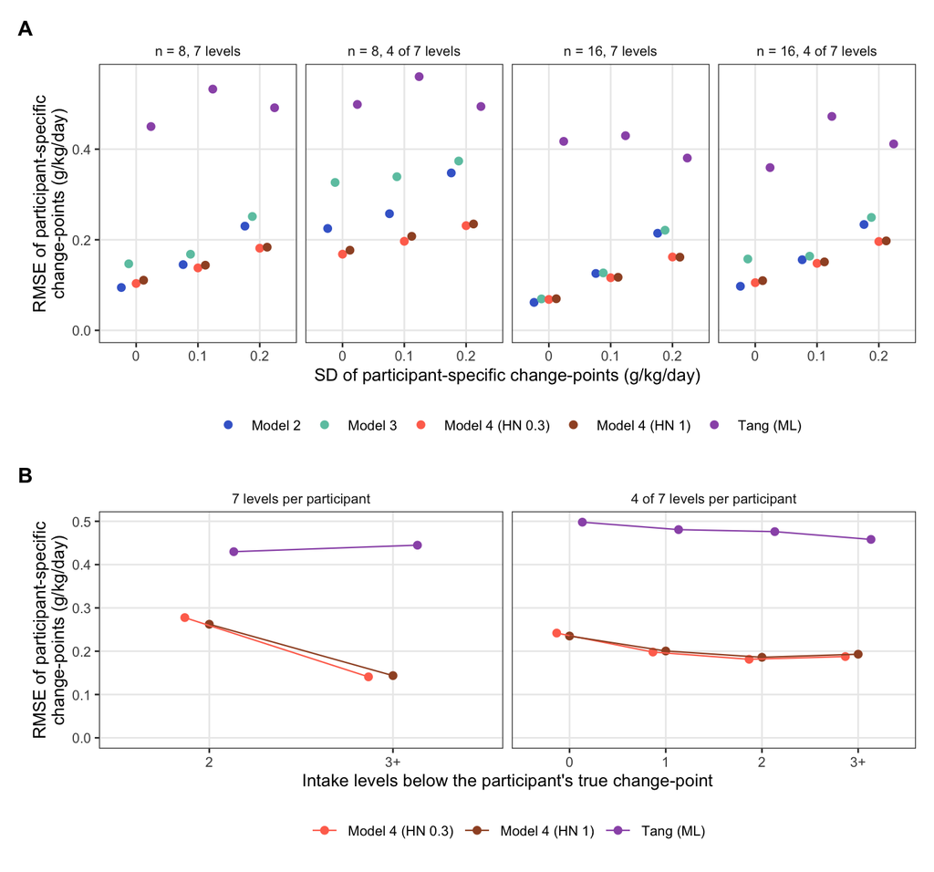

```r
p_ind <- perf_ind |>
  mutate(design = scen_lab(n, levels_per_participant)) |>
  ggplot(aes(factor(sd_cp), rmse, colour = method, group = method)) +
  geom_point(position = position_dodge(width = 0.6), size = 1.8) +
  facet_wrap(~ design, nrow = 1) +
  scale_colour_manual(values = method_colors, name = NULL) +
  expand_limits(y = 0) +
  labs(x = "SD of participant-specific change-points (g/kg/day)",
       y = "RMSE of participant-specific\nchange-points (g/kg/day)") +
  theme_bw(base_size = 10, base_family = "Arial") +
  theme(panel.grid.minor = element_blank(), legend.position = "bottom", strip.background = element_blank())
below_plot <- perf_ind_below |>
  filter(n_participants >= 30) |>
  mutate(design = factor(if_else(levels_per_participant == 7, "7 levels per participant", "4 of 7 levels per participant"),
                         levels = c("7 levels per participant", "4 of 7 levels per participant")))
p_below <- ggplot(below_plot, aes(levels_below, rmse, colour = method, group = method)) +
  geom_point(position = position_dodge(width = 0.4), size = 1.8) +
  geom_line(position = position_dodge(width = 0.4), linewidth = 0.4) +
  facet_wrap(~ design, nrow = 1, scales = "free_x") +
  scale_colour_manual(values = method_colors, name = NULL) +
  expand_limits(y = 0) +
  labs(x = "Intake levels below the participant's true change-point",
       y = "RMSE of participant-specific\nchange-points (g/kg/day)") +
  theme_bw(base_size = 10, base_family = "Arial") +
  theme(panel.grid.minor = element_blank(), legend.position = "bottom", strip.background = element_blank())
p_fig4 <- (p_ind / p_below) + plot_layout(heights = c(1, 0.85)) + plot_annotation(tag_levels = "A") &
  theme(plot.tag = element_text(face = "bold"))
p_fig4
```

# 5 Fig 2 of the manuscript

The figures above are for checking. Fig 2 of the manuscript is drawn by `figures/make_fig2_simulation.R` from the performance measures of the population-level change-point written below; the script can also be run on its own to adjust the figure.

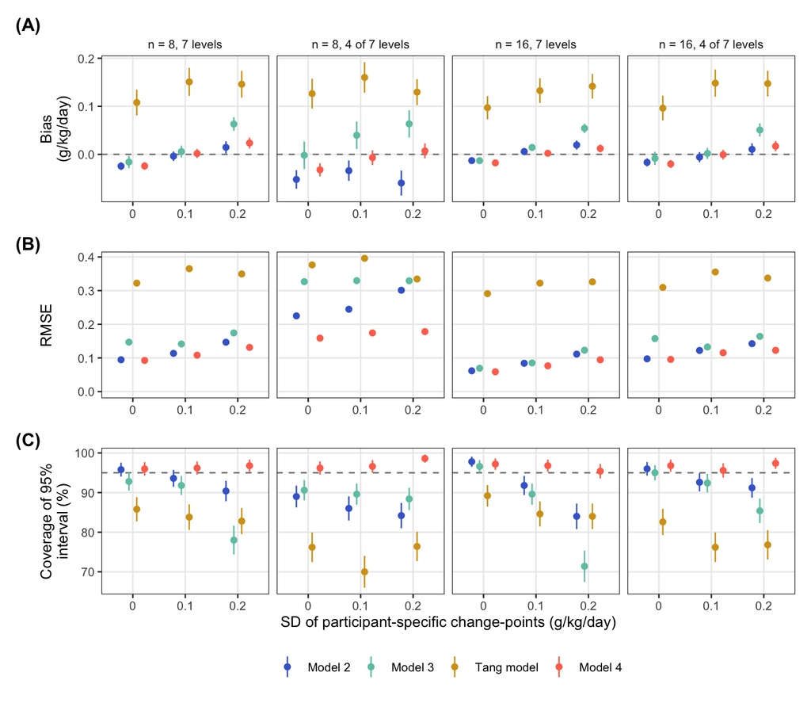

```r
dir.create("figures", showWarnings = FALSE)
perf_pop |>
  select(scenario, sd_cp, n, levels_per_participant, method, n_rep, n_est, bias, mcse_bias, emp_se, rmse,
         coverage, mcse_coverage, width, no_interval) |>
  write_csv("figures/sim_performance_population.csv")
fig2 <- local({
  e <- new.env()
  source("figures/make_fig2_simulation.R", chdir = TRUE, local = e)
  e$fig
})
fig2
```